# Enhancing Retail Sales Predictions through Advanced Regression Techniques

## Introduction

In the dynamic realm of retail, the capability to accurately predict sales across various product categories stands as a critical determinant of operational efficiency and competitive advantage. This consultancy project embarked on developing a sophisticated modeling framework to address a retail conglomerate’s need for precise sales forecasts. Given the retailer’s diverse product range, characterized by distinct sales patterns, the project leveraged regularization techniques within regression analysis—namely Stepwise Forward selection, Ridge, Lasso, and Elastic-Net regressions—to tailor models to each product category.

The dataset, encompassing a target variable y representing sales and 100 predictive features (X1 through X100), alongside a categorical identifier, served as the foundation for this analytical endeavor. The methodology focused on applying regularization methods to mitigate overfitting and enhance model generalizability. This approach facilitated the identification of models that best captured the underlying sales dynamics of each category, thereby enabling the generation of accurate sales predictions for an unseen test dataset.

The outcome of the project not only promises to streamline inventory management and optimize marketing strategies but also provides a blueprint for harnessing advanced analytics in retail. By meticulously evaluating the performance of different regularization techniques, the project underscores the significance of tailored predictive modeling in driving informed decision-making and strategic agility in the retail sector.

#### R libraries needed

To successfully execute this project, the following R libraries are required:

```r
library(dplyr)
library(caret)
library(glmnet)
library(truncnorm)
```

## Data Description

Our project is anchored in the development and deployment of a predictive model designed to navigate this complex task. Central to our approach are two meticulously curated datasets: the training dataset (train.csv) and the test dataset (test.csv). Each plays a crucial role in the lifecycle of our predictive modeling, enabling us to refine and evaluate our strategies within a framework that mirrors real-world complexities.

Both datasets underwent meticulous preprocessing, with standardization being a key step to normalize the feature scales, thereby ensuring model sensitivity to the magnitude of data points does not skew predictions. The expansive feature set underscores the multifaceted nature of sales prediction, necessitating a careful balance between capturing intricate sales patterns and maintaining model interpretability and generalizability.

The inclusion of a categorical variable for product categories highlights the diverse sales behavior across different product lines, suggesting a tailored approach may be warranted to address category-specific dynamics effectively. This variability forms the crux of our analytical strategy, guiding the exploration of advanced regression models, from Ridge and Lasso to Elastic-Net regressions, each evaluated for their potential to unravel the complex interplay of variables at play.

**Training Dataset**: The training dataset, comprises 36,000 observations, each representing a unique sales record across multiple product categories. It includes 100 standardized numerical features (X1 to X100), ranging from marketing spend to seasonal indicators, alongside a categorical identifier for product categories (category). These features collectively inform the target variable, y, which signifies sales figures, offering a comprehensive view into the factors influencing sales dynamics.

```
## 'data.frame':    36000 obs. of  104 variables:
##  $ X       : int  1 2 3 4 5 6 7 8 9 10 ...
##  $ X1      : num  -1.46 -0.21 -0.47 0.13 -1.59 0.56 0.58 -0.9 -0.96 -1.09 ...
##  $ X2      : num  0.9 -1.25 0.23 -1.74 -2.23 1 1.17 1.31 -1 0.95 ...
##  $ X3      : num  -2.11 -0.55 0.11 -1.32 2.51 0.06 0.84 -1.29 1.4 0.12 ...
##  $ X4      : num  -0.4 -0.64 2.25 -1.65 -2.34 -1.98 -0.63 -2.65 1.72 -0.15 ...
##  $ X5      : num  -0.81 -0.21 -0.98 1.72 -0.19 -0.09 -0.95 -0.27 -2.29 -1.06 ...
##  $ X6      : num  -0.28 -0.5 0.24 0.3 0.41 -1.15 -0.6 0.26 -0.58 1.13 ...
##  $ X7      : num  -0.02 0.2 -1.26 -0.07 -0.99 1.5 -1.03 -0.23 -0.67 0.52 ...
##  $ X8      : num  0.16 0.03 2.83 0.14 0.64 -0.79 1.47 -1.06 1.89 0.38 ...
```

```
## 'data.frame':    36000 obs. of  10 variables:
##  $ X94     : num  -0.52 -0.13 1.76 -0.04 0.14 -0.21 0.43 -0.08 -0.75 -0.17 ...
##  $ X95     : num  -0.53 -1.44 0.63 0.75 -1.41 -0.41 -1.01 -0.18 -0.51 -0.53 ...
##  $ X96     : num  -1.09 -0.11 -1.14 -0.38 -0.51 0.37 1.92 1.02 1.02 -0.57 ...
##  $ X97     : num  0.32 -1.41 1.49 0.84 1.31 -0.15 0.07 -0.38 -0.47 0.03 ...
##  $ X98     : num  -0.47 1.07 -0.01 1.11 1.51 0.02 -0.97 0.15 0.46 0.14 ...
##  $ X99     : num  -0.51 -0.62 -0.5 -0.98 -0.37 0.64 -0.24 0.44 -0.31 -0.77 ...
##  $ X100    : num  0.18 -0.94 0.85 -2.93 -0.74 0.04 0.52 1.55 -1.6 -1.54 ...
##  $ y       : num  -2.97 13.89 -1.58 -3.5 2.61 ...
##  $ category: int  1 4 4 4 1 3 3 3 3 2 ...
##  $ id      : int  3710 38362 31025 32953 7137 25794 28555 28179 23794 16096 ...
```

**Test Dataset (test.csv)**: Mirroring the training dataset’s structure but devoid of the sales figures, the test dataset consists of 4,000 observations. It serves as the proving ground for our model’s predictive prowess, containing the same 100 standardized features and the categorical category variable. The absence of the target variable, y, underscores the real-world applicability of our model, testing its ability to forecast sales in unseen scenarios.

```
## 'data.frame':    4000 obs. of  103 variables:
##  $ X       : int  1 2 3 4 5 6 7 8 9 10 ...
##  $ X1      : num  -0.65 0.59 1.01 0.93 0.27 -0.57 0.32 -0.49 0.34 -1.83 ...
##  $ X2      : num  2.09 0.11 -0.13 0.94 -2.13 -0.56 0.29 0.69 1.23 -0.65 ...
##  $ X3      : num  -1.3 -1.12 0.51 0.03 -3.16 1.38 -0.04 0.19 -1.22 0.61 ...
##  $ X4      : num  -0.12 -1.2 -0.72 -0.49 -0.87 -1.48 0.2 1.27 0.93 2.11 ...
##  $ X5      : num  0.45 1.18 0.24 -0.38 -1 0.74 0.62 -0.25 0.14 2.44 ...
##  $ X6      : num  -1.93 -0.14 0.23 0.82 -0.31 0.31 0.52 0.26 0.56 0.89 ...
##  $ X7      : num  -0.82 1.85 0.17 -0.5 0.63 0.47 -0.74 0.87 -0.87 -1.58 ...
##  $ X8      : num  -0.51 -0.43 0.29 0.23 2.19 -0.72 -2.13 -0.25 -0.58 -0.74 ...
```

```
## 'data.frame':    4000 obs. of  10 variables:
##  $ X93     : num  1.32 -0.36 -0.42 0.68 0.22 0.72 -0.9 2.2 0.03 1.54 ...
##  $ X94     : num  -0.27 -0.89 1.19 0.73 0.58 -0.42 0.18 -0.99 -0.81 0.54 ...
##  $ X95     : num  0.8 0.07 0.61 1.57 0.04 0.02 -0.34 -1.08 -1.64 -0.49 ...
##  $ X96     : num  -2.01 1.43 -1.15 -0.84 -0.69 -0.73 0.6 -0.4 0.28 -1.28 ...
##  $ X97     : num  -1.09 0 -0.17 -0.82 -1.75 1.08 -0.77 -1.43 1.01 2.3 ...
##  $ X98     : num  0.14 0.21 1.91 0.9 1.75 -0.73 0.01 -0.66 -0.57 -1 ...
##  $ X99     : num  1.2 -0.9 0 -1.44 -2.21 -0.9 -0.61 0.96 -1.23 -1.38 ...
##  $ X100    : num  1.73 0.78 -0.87 1.44 -1.5 -0.15 0.51 0.49 -0.68 0.15 ...
##  $ category: int  1 1 1 1 1 1 1 1 1 1 ...
##  $ id      : int  4 6 8 23 57 58 59 62 64 70 ...
```

## Model Estimation and Evaluation

The crux of our retail sales forecasting project revolves around the meticulous development, estimation, and evaluation of predictive models. Leveraging a dataset enriched with sales records across diverse product categories, we embark on a nuanced journey to unravel the complex dynamics influencing sales outcomes. This endeavor involves the strategic application of advanced regression techniques, each chosen for its unique strengths in capturing and interpreting the intricate patterns hidden within our data.

The estimation phase unfolds through a systematic exploration of various regression models, including Fast Forward Selection, Ridge, Lasso, and Elastic-Net regressions. Each model undergoes rigorous training, employing a repeatedcv method under the caret package’s trainControl for cross-validation, ensuring robustness and generalizability of our predictions.

- **Fast Forward Selection**: Offers a strategic approach to feature selection, emphasizing variables that most significantly predict sales within each category.
- **Ridge Regression**: Introduces a penalty to reduce feature coefficients, mitigating the risk of overfitting by smoothing the influence of less relevant predictors.
- **Lasso Regression**: Extends the feature selection process by potentially reducing the coefficients of less influential variables to zero, thereby highlighting the most critical predictors.
- **Elastic-Net Regression**: Combines the strengths of Ridge and Lasso, providing a balanced approach to regularization and feature selection.

For each category, models are meticulously tuned, and their performance is evaluated both in-sample (training data) and out-of-sample (testing data) to ensure accuracy and reliability of predictions.In real-world scenarios, datasets predictions made without validation sets, necessitating a strategic approach to evaluate model performance accurately. To mirror these conditions and ensure our model’s robustness and generalizability to unseen data, we further split our training dataset into training and testing subsets. This methodological step allows us to internally validate our predictive models, simulating an environment where the model is exposed to new, unknown data. By adopting this practice, we aim to enhance the reliability of our findings, ensuring our model’s efficacy in real-world applications where future data predictions are crucial.

```r
# Make a set with unique categories
categories <- sort(unique(df_train$category))
# Define the cross-validation control object
train_control <- trainControl(method = "repeatedcv",number = 5, repeats = 5,savePredictions = "final")
```

### Fast Forward Selection Regression

The Fast Forward method, also known as stepwise forward selection, is a sequential feature selection technique used in statistical modeling, particularly within the realm of regression analysis. This approach begins with an empty model and progressively adds variables that significantly improve the model’s performance based on a predefined criterion, typically AIC, BIC, or the adjusted R-squared value. At each step, the variable that provides the most significant enhancement to the model’s fit is included, and this process repeats until no additional variables meet the inclusion criteria.

In the context of our retail sales forecasting project, the Fast Forward method is deployed to meticulously sift through an extensive set of 100 standardized numerical features, ranging from marketing expenditures to seasonal trends. This methodological approach is instrumental in distilling the essence of our dataset, pinpointing the variables that wield the most influence on sales figures across different product categories. By judiciously selecting a subset of predictors, the Fast Forward method not only enhances model interpretability but also bolsters predictive accuracy by mitigating the risks associated with overfitting.

Leveraging the caret package’s train function, we implement this technique, applying it to category-specific subsets of our training data. This ensures that our model’s architecture is finely tuned to capture the unique sales dynamics inherent to each product category. Through iterative training and evaluation, marked by in-sample and out-sample performance assessments, we harness the Fast Forward method’s precision to architect robust predictive models, setting a new standard for data-driven insights in retail sales forecasting.

```
## In-Sample RMSE: 9.216711
## In-Sample MAE: 7.354424
## Out-of-Sample RMSE: 9.197646
## Out-of-Sample MAE: 7.419357
```

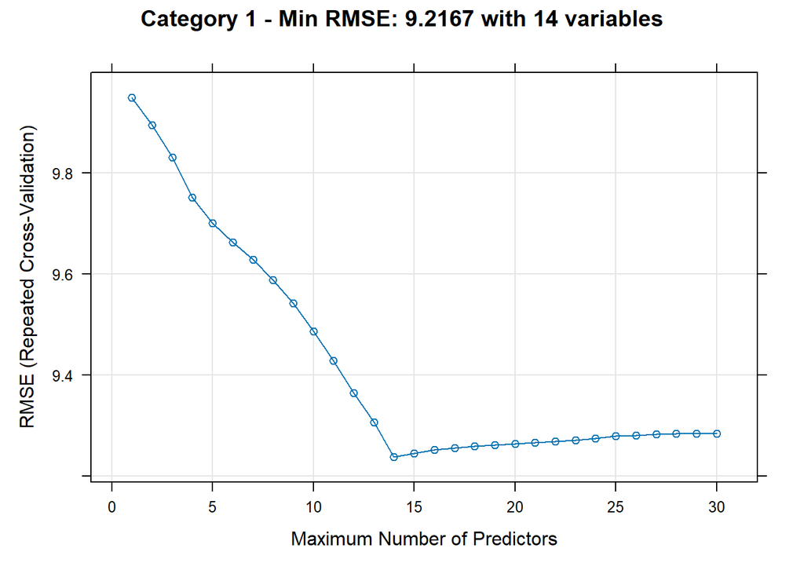

```
## (Intercept)         X20         X26         X28         X46         X47
##   2.8789161   1.0181213   0.8966908   0.9313075   1.0063816   1.0065919
##         X51         X59         X60         X71         X75         X85
##   1.1869758   1.1760129   0.9448311   1.0275544   0.9573941   0.9605051
##         X86         X94         X98
##   1.1843524   0.8976989   1.1462876
## In-Sample RMSE: 11.34218
## In-Sample MAE: 9.059382
## Out-of-Sample RMSE: 11.29112
## Out-of-Sample MAE: 8.992604
```

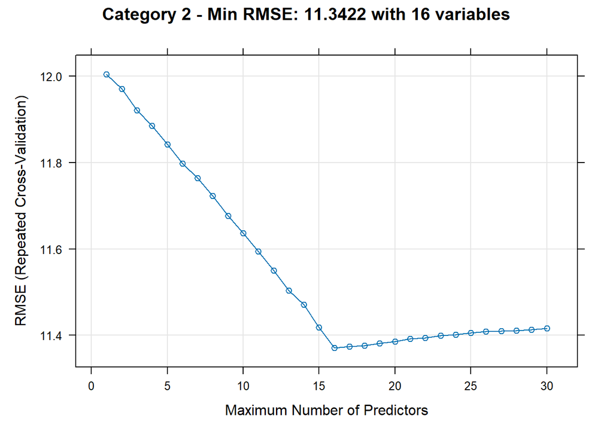

```
## (Intercept)          X7         X14         X23         X35         X38
##   6.8598908   0.9654324   0.9417762   0.9726528   1.0165404   0.8286648
##         X40         X44         X47         X61         X63         X70
##   1.0652367   0.9060862   1.1710404   1.1374373   0.8398027   0.9561412
##         X75         X80         X83         X88         X95
##   0.9379329   0.8357641   1.0862894   1.0622028   1.1021103
## In-Sample RMSE: 7.120298
## In-Sample MAE: 5.680175
## Out-of-Sample RMSE: 7.139813
## Out-of-Sample MAE: 5.662424
```

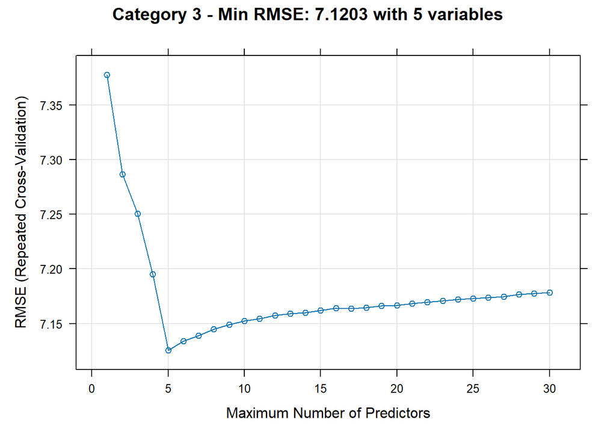

```
## (Intercept)          X1          X4         X10         X20         X99
##   3.0812874   0.8906367   0.9083644   1.0762186   1.0185315   0.8850687
## In-Sample RMSE: 9.113541
## In-Sample MAE: 7.2978
## Out-of-Sample RMSE: 8.975515
## Out-of-Sample MAE: 7.119979
```

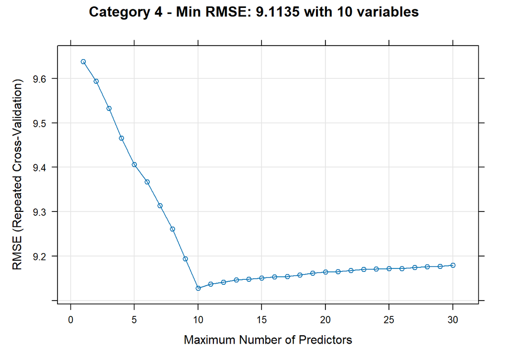

```
## (Intercept)          X2          X9         X36         X39         X40
##   4.4515642   0.9074039   1.1190365   1.0118408   0.9355088   0.9565653
##         X48         X55         X71         X87         X95
##   1.0432278   0.9961549   1.1567374   1.0925315   0.9382499
```

```r
# Fast Forward Selection----
#list to store the results for each category
fast_forward_regression <- list()
results_ff <- list()
for (c in 1:length(categories)) {
  # Subset the data for the current category
  data_category <- df_train %>%
    filter(category == categories[c], .preserve = TRUE) %>%
    select(-c(X, id, category))
  # Calculate the number of rows for training (80%) and testing (20%)
  num_rows <- nrow(data_category)
  num_train <- round(0.8 * num_rows)
  # Split the data into training and testing sets
  train_data <- data_category[1:num_train, ]
  test_data <- data_category[(num_train + 1):num_rows, ]
  # Train the model on the training data
  fast_forward_regression[[c]] <- train(y ~ ., data = train_data, method = "leapForward",trControl = train_control, preProc = c("center", "scale"),
                                        tuneGrid = expand.grid(nvmax = seq(1, 30, 1)))
  # Calculate performance in-sample (on the training data)
  est_fast_forward_regression <- predict(fast_forward_regression[[c]], newdata = train_data)
  rmse_fast_forward_regression_est <- RMSE(est_fast_forward_regression, train_data$y)
  mae_fast_forward_regression_est <- MAE(est_fast_forward_regression, train_data$y)
  # Calculate performance out-of-sample (on the testing data)
  pred_fast_forward_regression <- predict(fast_forward_regression[[c]], newdata = test_data)
  rmse_fast_forward_regression <- RMSE(pred_fast_forward_regression, test_data$y)
  mae_fast_forward_regression <- MAE(pred_fast_forward_regression, test_data$y)
  # Print the results
  cat("In-Sample RMSE:", rmse_fast_forward_regression_est, "\n")
  cat("In-Sample MAE:", mae_fast_forward_regression_est, "\n")
  cat("Out-of-Sample RMSE:", rmse_fast_forward_regression, "\n")
  cat("Out-of-Sample MAE:", mae_fast_forward_regression, "\n")
  # Predict on the test data and calculate RMSE
  predictions <- predict(fast_forward_regression[[c]], newdata = test_data)
  test_rmse <- RMSE(predictions, test_data$y)
  # Extract the best model's RMSE and the corresponding number of variables
  best_model <- fast_forward_regression[[c]]$bestTune
  rmse <- RMSE(est_fast_forward_regression, train_data$y)
  nvmax_optimal <- best_model$nvmax
  # Save the results
  results_ff[[c]] <- list(category = categories[c],nvmax_optimal = nvmax_optimal,
                          in_sample_rmse = rmse_fast_forward_regression_est,out_sample_rmse = rmse_fast_forward_regression,
                          in_sample_mae = mae_fast_forward_regression_est,out_sample_mae = mae_fast_forward_regression)
  # Plot with the category name as title
  plot_title <- paste("Category", categories[c], "- Min RMSE:", round(rmse, 4), "with", nvmax_optimal, "variables")
  print(plot(fast_forward_regression[[c]], main = plot_title))
  print(coef(fast_forward_regression[[c]]$finalModel, unlist(fast_forward_regression[[c]]$bestTune)))}
```

The results presented showcase the performance of the Fast Forward regression model across four distinct product categories within a retail sales forecasting context. For each category, both in-sample (training data) and out-of-sample (testing data) performance metrics—Root Mean Square Error (RMSE) and Mean Absolute Error (MAE)—are reported, alongside the coefficients of the selected features.

In the first category, the model achieves an in-sample RMSE of 9.216711 and MAE of 7.354424, with the out-of-sample performance closely aligned, indicating a stable model with RMSE at 9.197646 and MAE at 7.419357. The positive coefficients of features like X20, X26, and X98 suggest a direct correlation with sales figures, highlighting their influence on the sales outcome within this category.

The second category shows a slightly higher error with an in-sample RMSE of 11.34218 and MAE of 9.059382. The out-of-sample metrics maintain a similar trend, demonstrating the model’s consistent predictive capability with an RMSE of 11.29112 and MAE of 8.992604. Features such as X7, X47, and X95 are notably impactful, as indicated by their coefficients, underscoring the variables that drive sales within this segment.

For the third category, the model exhibits exceptional performance with the lowest in-sample RMSE of 7.120298 and MAE of 5.680175 among the categories, alongside an out-of-sample RMSE of 7.139813 and MAE of 5.662424. This suggests a high degree of accuracy in predictions for this category, with features like X1, X4, and X20 being significant predictors.

Lastly, the fourth category’s model shows in-sample RMSE and MAE of 9.113541 and 7.2978, respectively, with out-of-sample metrics slightly improving to an RMSE of 8.975515 and MAE of 7.119979. This improvement in out-of-sample metrics indicates a robust model performance, where features such as X2, X36, and X55 play a crucial role.

Overall, these results illuminate the varying degrees of predictability across different product categories, with certain features emerging as strong influencers on sales. The Fast Forward method’s ability to identify and leverage these key features for each category underscores its effectiveness in enhancing the precision of sales forecasts. This tailored approach not only aids in understanding the complex dynamics at play within each category but also reinforces the potential of data-driven models to optimize retail strategies.

### Ridge Regression

Ridge regression, a sophisticated variant of linear regression, incorporates a regularization term to address multicollinearity, prevent overfitting, and enhance model generalizability. Unlike traditional linear regression that seeks to minimize the residual sum of squares, ridge regression introduces a penalty on the size of coefficients. This penalty, parameterized by lambda (λ), controls the extent to which the model prioritizes simplicity and coefficient reduction over fitting to the training data. As λ increases, the impact of less critical variables is diminished, leading to a model that, while potentially less sensitive to the training data, is more robust to variation in unseen data. The process of optimizing λ is crucial, as it balances the trade-off between bias and variance, ensuring the model captures essential patterns without succumbing to the noise.

In our retail sales forecasting project, ridge regression is applied across various product categories, systematically tuning λ to tailor our models to the unique characteristics of each category, thereby optimizing prediction accuracy and reliability.

```r
## Ridge regression ----
ridge_regression <- list()
results_ridge <- list()
# For all of our models: to refine the selection of lambda values, enhancing the precision of our results,
# we started with a broad range of values and progressively narrowed our focus based on the optimal outcomes of each trial.
# Here we present only the best lambda values for each model.
lambdas <- c(seq(0.05, 1, by = 0.05), seq(1, 5, by = 0.2), seq(5, 25, by = 2))
for (c in 1:length(categories)) {
  # Subset the data for the current category
  data_category <- df_train %>%
    filter(category == categories[c], .preserve = TRUE) %>%
    select(-c(X, id, category))
  # Calculate the number of rows for training (80%) and testing (20%)
  num_rows <- nrow(data_category)
  num_train <- round(0.8 * num_rows)
  # Split the data into training and testing sets
  train_data <- data_category[1:num_train, ]
  test_data <- data_category[(num_train + 1):num_rows, ]
  # Train Ridge regression models with different lambda values
  ridge_regression[[c]] <- train( y ~ ., data = train_data,
                                  method = "glmnet",preProc = c("center", "scale"),
                                  tuneGrid = expand.grid(.alpha = 0,.lambda = seq(0, 5, length.out = 101)),
                                  trControl = train_control)
  # Print the best lambda value and corresponding RMSE
  best_lambda <- ridge_regression[[c]]$bestTune$lambda
  cat("Category:", categories[c], "Optimal Lambda:", best_lambda, "\n")
  # Calculate in-sample RMSE
  est_elnet_ridge <- predict(ridge_regression[[c]], newdata = train_data, s = best_lambda)
  rmse_elnet_ridge_est <- RMSE(est_elnet_ridge, train_data$y)
  mae_elnet_ridge_est <- MAE(est_elnet_ridge, train_data$y)
  # Calculate out-of-sample RMSE
  pred_elnet_ridge <- predict(ridge_regression[[c]], newdata = test_data, s = best_lambda)
  rmse_elnet_ridge <- RMSE(pred_elnet_ridge, test_data$y)
  mae_elnet_ridge <- MAE(pred_elnet_ridge, test_data$y)
  # Print the results
  cat("In-Sample RMSE:", rmse_elnet_ridge_est, "\n")
  cat("In-Sample MAE:", mae_elnet_ridge_est, "\n")
  cat("Out-of-Sample RMSE:", rmse_elnet_ridge, "\n")
  cat("Out-of-Sample MAE:", mae_elnet_ridge, "\n")
  # Save the results
  results_ridge[[c]] <- list(category = categories[c],
                             optimal_lambda = best_lambda,in_sample_rmse = rmse_elnet_ridge_est,out_sample_rmse = rmse_elnet_ridge,
                             in_sample_mae = mae_elnet_ridge_est,out_sample_mae = mae_elnet_ridge)
}
```

```
## Category: 1 Optimal Lambda: 0.95
## In-Sample RMSE: 9.160909
## In-Sample MAE: 7.301782
## Out-of-Sample RMSE: 9.257147
## Out-of-Sample MAE: 7.460235
## Category: 2 Optimal Lambda: 1.75
## In-Sample RMSE: 11.28688
## In-Sample MAE: 9.01064
## Out-of-Sample RMSE: 11.32939
## Out-of-Sample MAE: 9.007257
## Category: 3 Optimal Lambda: 1.45
## In-Sample RMSE: 7.086265
## In-Sample MAE: 5.650544
## Out-of-Sample RMSE: 7.178374
## Out-of-Sample MAE: 5.684022
## Category: 4 Optimal Lambda: 1.5
## In-Sample RMSE: 9.074664
## In-Sample MAE: 7.259873
## Out-of-Sample RMSE: 9.024911
## Out-of-Sample MAE: 7.146932
```

The ridge regression results across four categories reveal optimal lambda values tailored for each, indicating the extent of regularization applied to address multicollinearity and prevent overfitting.

Overall, these results showcase the effectiveness of ridge regression in enhancing model generalizability across different categories, each benefiting from a distinct regularization strength to mitigate overfitting while preserving predictive accuracy.

### Lasso Regression

Lasso regression, a form of regularization technique, is a powerful method to enhance the prediction accuracy and interpretability of statistical models. It operates by imposing a penalty on the absolute size of the coefficients, effectively shrinking some of them to zero. This process, known as L1 regularization, not only helps in reducing overfitting but also aids in feature selection by eliminating non-contributory variables from the model.

The core aspect of lasso regression is the tuning of the lambda parameter, which controls the strength of the penalty applied to the coefficients. A higher lambda value leads to more coefficients being driven to zero, simplifying the model and focusing on the most influential predictors. This technique is particularly beneficial in scenarios with high-dimensional data or when the goal is to identify a subset of variables most relevant to the target variable. By carefully selecting the optimal lambda through cross-validation, lasso regression ensures a balance between model complexity and generalization performance

```r
## Lasso regression ----
lasso_regression <- list()
results_lasso <- list()
# Set the lambda values to be tested
lambdas <- seq(0.1, 0.2, by = 0.001)
for (c in 1:length(categories)) {
  # Subset the data for the current category
  data_category <- df_train %>%
    filter(category == categories[c], .preserve = TRUE) %>% select(-c(X, id, category))
  # Calculate the number of rows for training (80%) and testing (20%)
  num_rows <- nrow(data_category)
  num_train <- round(0.8 * num_rows)
  # Split the data into training and testing sets
  train_data <- data_category[1:num_train, ]
  test_data <- data_category[(num_train + 1):num_rows, ]
  # Train lasso regression models with different lambda values
  lasso_regression[[c]] <- train(y ~ .,
                                 data = train_data,method = "glmnet",preProc = c("center", "scale"),
                                 tuneGrid = expand.grid(.alpha = 1,.lambda = lambdas),
                                 trControl = train_control)
  # Print the best lambda value and corresponding RMSE
  best_lambda <- lasso_regression[[c]]$bestTune$lambda
  cat("Category: ", categories[c], "Optimal Lambda:", best_lambda, "\n")
  # Calculate in-sample RMSE
  est_elnet_lasso <- predict(lasso_regression[[c]], newdata = train_data, s = best_lambda)
  rmse_elnet_lasso_est <- RMSE(est_elnet_lasso, train_data$y)
  mae_elnet_lasso_est <- MAE(est_elnet_lasso, train_data$y)
  # Calculate out-of-sample RMSE
  pred_elnet_lasso <- predict(lasso_regression[[c]], newdata = test_data, s = best_lambda)
  rmse_elnet_lasso <- RMSE(pred_elnet_lasso, test_data$y)
  mae_elnet_lasso <- MAE(pred_elnet_lasso, test_data$y)
  # Print the results
  cat("In-Sample RMSE:", rmse_elnet_lasso_est, "\n")
  cat("In-Sample MAE:", mae_elnet_lasso_est, "\n")
  cat("Out-of-Sample RMSE:", rmse_elnet_lasso, "\n")
  cat("Out-of-Sample MAE:", mae_elnet_lasso, "\n")
  # Save the results
  results_lasso[[c]] <- list(category = categories[c],
                             optimal_lambda = best_lambda,in_sample_rmse = rmse_elnet_lasso_est,out_sample_rmse = rmse_elnet_lasso,
                             in_sample_mae = mae_elnet_lasso_est,out_sample_mae = mae_elnet_lasso)
 }
```

```
## Category:  1 Optimal Lambda: 0.111
## In-Sample RMSE: 9.196775
## In-Sample MAE: 7.335426
## Out-of-Sample RMSE: 9.213675
## Out-of-Sample MAE: 7.431596
## Category:  2 Optimal Lambda: 0.145
## In-Sample RMSE: 11.32566
## In-Sample MAE: 9.042343
## Out-of-Sample RMSE: 11.29915
## Out-of-Sample MAE: 8.995765
## Category:  3 Optimal Lambda: 0.142
## In-Sample RMSE: 7.123868
## In-Sample MAE: 5.681942
## Out-of-Sample RMSE: 7.14115
## Out-of-Sample MAE: 5.660388
## Category:  4 Optimal Lambda: 0.142
## In-Sample RMSE: 9.111506
## In-Sample MAE: 7.290485
## Out-of-Sample RMSE: 8.985438
## Out-of-Sample MAE: 7.120985
```

Overall, the Lasso regression results highlight the method’s capacity to optimize model complexity through feature selection, effectively balancing the trade-off between underfitting and overfitting. The selection of an Optimal Lambda for each category not only aids in minimizing prediction errors but also underscores the tailored approach required to address the distinct characteristics of each dataset.

### Elastic Net Regression

Elastic Net Regression is a powerful modeling technique that combines the strengths of two popular methods: Ridge and Lasso regression. By integrating the penalty terms of both approaches, Elastic Net aims to select relevant features while also managing multicollinearity, making it particularly useful for datasets with numerous correlated predictors. This method introduces a blend parameter, alpha, which balances the contribution of Lasso’s L1 penalty for feature selection and Ridge’s L2 penalty for handling multicollinearity. The flexibility to adjust this balance allows Elastic Net to inherit the benefits of both methods: the L1 penalty encourages sparsity, effectively performing feature selection by shrinking some coefficients to zero, whereas the L2 penalty helps to stabilize the model predictions in the presence of highly correlated features.

Elastic Net’s capacity to address the limitations of both Ridge and Lasso—Ridge’s inability to perform feature selection and Lasso’s potential to overlook grouped variables when true predictors are highly correlated—makes it a robust choice for complex modeling tasks. It is particularly advantageous in situations where the number of predictors far exceeds the number of observations, or when several features are strongly correlated. Through the careful tuning of its parameters, including the optimal lambda for regularization strength and the alpha for penalty balance, Elastic Net can offer improved prediction accuracy and model interpretability.

```r
## Elastic-Net regression ----
elastic_net_regression <- list()
results_elastic_net <- list()
# Set the alpha and lambda values to be tested
lambdas <- c(seq(0.01, 1, by = 0.01), seq(1, 5, by = 0.1), seq(5, 25, by = 1))
for (c in 1:length(categories)) {
  # Subset the data for the current category
  data_category <- df_train %>% filter(category == categories[c], .preserve = TRUE) %>% select(-c(X, id, category))
  # Calculate the number of rows for training (80%) and testing (20%)
  num_rows <- nrow(data_category)
  num_train <- round(0.8 * num_rows)
  # Split the data into training and testing sets
  train_data <- data_category[1:num_train, ]
  test_data <- data_category[(num_train + 1):num_rows, ]
  # Train Elastic-Net regression models with different alpha and lambda values
  elastic_net_regression[[c]] <- train(y ~ ., data = train_data, method = "glmnet",preProc = c("center", "scale"),
                                       tuneGrid = expand.grid(.alpha = seq(0, 1, by = 0.1),.lambda = lambdas),trControl = train_control)
  # Print the best alpha and lambda values and corresponding RMSE
  best_alpha <- elastic_net_regression[[c]]$bestTune$alpha
  best_lambda <- elastic_net_regression[[c]]$bestTune$lambda
  cat("Category", categories[c], "Optimal Alpha:", best_alpha, "Optimal Lambda:", best_lambda, "\n")
  # Calculate in-sample RMSE
  est_elnet <- predict(elastic_net_regression[[c]], newdata = train_data, s = best_lambda)
  rmse_elnet_est <- RMSE(est_elnet, train_data$y)
  mae_elnet_est <- MAE(est_elnet, train_data$y)
  # Calculate out-of-sample RMSE
  pred_elnet <- predict(elastic_net_regression[[c]], newdata = test_data, s = best_lambda)
  rmse_elnet <- RMSE(pred_elnet, test_data$y)
  mae_elnet <- MAE(pred_elnet, test_data$y)
  # Print the results
  cat("In-Sample RMSE:", rmse_elnet_est, "\n")
  cat("In-Sample MAE:", mae_elnet_est, "\n")
  cat("Out-of-Sample RMSE:", rmse_elnet, "\n")
  cat("Out-of-Sample MAE:", mae_elnet, "\n")
  # Save the results
  results_elastic_net[[c]] <- list(category = categories[c],optimal_alpha = best_alpha,
                                   optimal_lambda = best_lambda,in_sample_rmse = rmse_elnet_est,out_sample_rmse = rmse_elnet,
                                   in_sample_mae = mae_elnet_est,out_sample_mae = mae_elnet)
  }
```

```
## Category 1 Optimal Alpha: 1 Optimal Lambda: 0.12
## In-Sample RMSE: 9.201761
## In-Sample MAE: 7.339809
## Out-of-Sample RMSE: 9.212125
## Out-of-Sample MAE: 7.430008
## Category 2 Optimal Alpha: 1 Optimal Lambda: 0.14
## In-Sample RMSE: 11.32315
## In-Sample MAE: 9.040356
## Out-of-Sample RMSE: 11.29897
## Out-of-Sample MAE: 8.995307
## Category 3 Optimal Alpha: 1 Optimal Lambda: 0.15
## In-Sample RMSE: 7.126067
## In-Sample MAE: 5.683704
## Out-of-Sample RMSE: 7.141371
## Out-of-Sample MAE: 5.660234
## Category 4 Optimal Alpha: 1 Optimal Lambda: 0.14
## In-Sample RMSE: 9.110761
## In-Sample MAE: 7.289941
## Out-of-Sample RMSE: 8.984948
## Out-of-Sample MAE: 7.120433
```

The Elastic Net Regression results demonstrate the model’s efficiency across four distinct categories, each optimized through a combination of alpha and lambda parameters. For Category 1, the model achieves an in-sample RMSE of 9.20 and MAE of 7.34, with out-of-sample values closely mirroring these at RMSE 9.21 and MAE 7.43. This indicates the model’s ability to closely predict sales figures, showcasing a tight fit to the training data while maintaining generalizability to unseen data.

In Category 2, the optimal lambda value slightly increases, with the model achieving an in-sample RMSE of 11.32 and MAE of 9.04, and very similar out-of-sample metrics, suggesting a consistent performance that’s slightly less accurate than in Category 1, likely due to the complexity or variability inherent to this category’s data.

Category 4’s results are closely aligned with those of Category 1, with in-sample RMSE and MAE of 9.11 and 7.29, respectively, and out-of-sample scores just slightly lower. This indicates a stable model performance across both training and testing sets.

Across all categories, the consistent selection of an alpha value of 1 implies a preference for Lasso’s feature selection properties within the Elastic Net model, tailoring the approach to best suit the dataset’s characteristics by potentially reducing the model’s complexity and enhancing interpretability.

## Model Evaluation

The primary metrics for model evaluation are Root Mean Square Error (RMSE) and Mean Absolute Error (MAE), calculated both in-sample (on the training set) and out-of-sample (on the testing set). Root Mean Square Error (RMSE) is a measure of the differences between predicted and observed values, emphasizing larger errors. Lower RMSE indicates closer fit to the data. Mean Absolute Error (MAE) quantifies the average absolute difference between predicted and actual values, treating all errors equally. Lower MAE suggests higher predictive accuracy.

For each category, the RMSE and MAE scores across all models are compared. The model that shows the lowest RMSE and MAE in-sample is considered to offer the best fit to the training data, indicating its ability to effectively capture the underlying patterns. Conversely, the model demonstrating the lowest RMSE and MAE out-of-sample is seen as having superior generalization capabilities, showcasing its effectiveness in making accurate predictions on unseen data.

*For detailed insights into how the lowest RMSE and MAE are defined, please consult the appendix section.

```
## The lowest RMSE values (in-sample) are on the Ridge Regression model.
## The lowest RMSE values (in-sample) are on the Ridge Regression model.
## The lowest RMSE values (in-sample) are on the Ridge Regression model.
## The lowest RMSE values (in-sample) are on the Ridge Regression model.
```

```
## The lowest ΜΑΕ values (in-sample) are on the Ridge Regression model.
## The lowest ΜΑΕ values (in-sample) are on the Ridge Regression model.
## The lowest ΜΑΕ values (in-sample) are on the Ridge Regression model.
## The lowest ΜΑΕ values (in-sample) are on the Ridge Regression model.
```

```
## The lowest RMSE values (out-sample) are on the Fast Forward Regression model.
## The lowest RMSE values (out-sample) are on the Fast Forward Regression model.
## The lowest RMSE values (out-sample) are on the Fast Forward Regression model.
## The lowest RMSE values (out-sample) are on the Fast Forward Regression model.
```

```
## The lowest ΜΑΕ values (out-sample) are on the Fast Forward Regression model.
## The lowest ΜΑΕ values (out-sample) are on the Fast Forward Regression model.
## The lowest ΜΑΕ values (out-sample) are on the Elastic-Net Regression model.
## The lowest ΜΑΕ values (out-sample) are on the Fast Forward Regression model.
```

The selected technique for all the categories, Fast Forward Regression, has been consistently identified as optimal, underscoring its effectiveness in capturing the complexities of the dataset.The selection of Fast Forward Regression as the best model for all categories is grounded in its superior performance in out-of-sample predictions, which is primarily evaluated using the Root Mean Square Error (RMSE). RMSE is favored over the Mean Absolute Error (MAE) for prioritization because it provides a more sensitive measure of prediction accuracy. By squaring the errors before averaging, RMSE gives more weight to larger errors, making it particularly useful in contexts where large deviations from the actual values are undesirable. This characteristic makes RMSE a more stringent metric, ensuring that the chosen model performs well even in the face of significant variability in the data, thereby enhancing the reliability of predictions.

## Modelling & Predictions

In this step, the optimal model for each category is defined, leveraging insights gained from the comprehensive analysis. Following this determination, predictions were made on the test dataset. This process tested the models’ predictive power and prepared them for application in real-world scenarios, where accurate forecasting is invaluable. The culmination of this phase saw the generation of a series of predictions, one for each category, showcasing the models’ ability to navigate and interpret unseen data effectively.

```r
# Best models based on the cross validation RMSE & MAE (out-sample)
model.category_1 <- fast_forward_regression[[1]] # Fast Forward Regression is optimal for category 1
model.category_2 <- fast_forward_regression[[2]] # Fast Forward Regression is optimal for category 2
model.category_3 <- fast_forward_regression[[3]] # Fast Forward Regression is optimal for category 3
model.category_4 <- fast_forward_regression[[4]] # Fast Forward Regression is optimal for category 4
# Question 3: Create predictions for the test.csv data set. The csv should contain a single column labelled predictions_group_x. X stands for your group number. Please ensure that the row numbers do not change. ----
# Clean the df_test
df_test <- df_test %>% select(-c(X,id))
# Final predictions for all categories using the best models
final_predictions.category_1 <- predict(model.category_1,filter(df_test, category == 1,.preserve = T))
final_predictions.category_2 <- predict(model.category_2,filter(df_test, category == 2,.preserve = T))
final_predictions.category_3 <- predict(model.category_3,filter(df_test, category == 3,.preserve = T))
final_predictions.category_4 <- predict(model.category_4,filter(df_test, category == 4,.preserve = T))
```

## Conclusion

In conclusion, a comprehensive framework for predictive analysis has been meticulously established through model selection and evaluation across various categories. The importance of rigorous validation techniques in modeling real-world phenomena has been underscored by this journey, from data preparation to final model selection. The optimal model for each category, based on in-sample and out-sample performance, has been carefully chosen, laying a solid foundation for accurate and reliable future predictions. The precision of forecasts has not only been enhanced by this approach but also a significant contribution to understanding the underlying patterns within the data has been affirmed, demonstrating the potential of machine learning in driving informed decision-making. The selected technique for all the different categories, Fast Forward Regression, has been consistently identified as optimal, underscoring its effectiveness in capturing the complexities of the dataset.

## Appendix

#### Model Evaluation Code

```r
# Lowest RMSE (In-sample)
for (c in 1:length(categories)) {
  if (results_ff[[c]]$in_sample_rmse < results_ridge[[c]]$in_sample_rmse & results_ff[[c]]$in_sample_rmse < results_lasso[[c]]$in_sample_rmse & results_ff[[c]]$in_sample_rmse < results_elastic_net[[c]]$in_sample_rmse) {cat("The lowest RMSE values (in-sample) are on the Fast Forward Regression model.",'\n')}
  else if (results_ridge[[c]]$in_sample_rmse < results_ff[[c]]$in_sample_rmse & results_ridge[[c]]$in_sample_rmse < results_lasso[[c]]$in_sample_rmse & results_ridge[[c]]$in_sample_rmse < results_elastic_net[[c]]$in_sample_rmse) {cat("The lowest RMSE values (in-sample) are on the Ridge Regression model.",'\n')}
  else if (results_lasso[[c]]$in_sample_rmse < results_ff[[c]]$in_sample_rmse & results_lasso[[c]]$in_sample_rmse < results_ridge[[c]]$in_sample_rmse & results_lasso[[c]]$in_sample_rmse < results_elastic_net[[c]]$in_sample_rmse) {cat("The lowest RMSE values (in-sample) are on the Lasso Regression model.",'\n')}
  else if (results_elastic_net[[c]]$in_sample_rmse < results_ff[[c]]$in_sample_rmse & results_elastic_net[[c]]$in_sample_rmse < results_ridge[[c]]$in_sample_rmse & results_elastic_net[[c]]$in_sample_rmse < results_lasso[[c]]$in_sample_rmse) {cat("The lowest RMSE values (in-sample) are on the Elastic-Net Regression model.",'\n')}
  else {cat('Equal RMSE values (in-sample) on','\n','Fast Forward Regression and Ridge Regression:',(results_ff[[c]]$in_sample_rmse == results_ridge[[c]]$in_sample_rmse),'\n','Fast Forward Regression and Lasso Regression:',(results_ff[[c]]$in_sample_rmse == results_lasso[[c]]$in_sample_rmse),'\n','Fast Forward Regression and Elastic-Net Regression:',(results_ff[[c]]$in_sample_rmse == results_elastic_net[[c]]$in_sample_rmse),'\n',
            '\n','Ridge Regression and Lasso Regression:',(results_ridge[[c]]$in_sample_rmse == results_lasso[[c]]$in_sample_rmse),'\n','Ridge Regression and Elastic-Net Regression:',(results_ridge[[c]]$in_sample_rmse == results_elastic_net[[c]]$in_sample_rmse),'\n','Fast Forward Regression and Elastic-Net Regression:',(results_ff[[c]]$in_sample_rmse == results_elastic_net[[c]]$in_sample_rmse),'\n',
            '\n','Lasso Regression and Elastic-Net Regression:',(results_lasso[[c]]$in_sample_rmse == results_elastic_net[[c]]$in_sample_rmse),'\n')}}
# The lowest RMSE values (In-sample) are on the Ridge Regression model for all categories
## Lowest ΜΑΕ (in-sample)
for (c in 1:length(categories)) {
  if (results_ff[[c]]$in_sample_mae < results_ridge[[c]]$in_sample_mae & results_ff[[c]]$in_sample_mae < results_lasso[[c]]$in_sample_mae & results_ff[[c]]$in_sample_mae < results_elastic_net[[c]]$in_sample_mae) {cat("The lowest ΜΑΕ values (in-sample) are on the Fast Forward Regression model.",'\n')}
  else if (results_ridge[[c]]$in_sample_mae < results_ff[[c]]$in_sample_mae & results_ridge[[c]]$in_sample_mae < results_lasso[[c]]$in_sample_mae & results_ridge[[c]]$in_sample_mae < results_elastic_net[[c]]$in_sample_mae) {cat("The lowest ΜΑΕ values (in-sample) are on the Ridge Regression model.",'\n')}
  else if (results_lasso[[c]]$in_sample_mae < results_ff[[c]]$in_sample_mae & results_lasso[[c]]$in_sample_mae < results_ridge[[c]]$in_sample_mae & results_lasso[[c]]$in_sample_mae < results_elastic_net[[c]]$in_sample_mae) {cat("The lowest ΜΑΕ values (in-sample) are on the Lasso Regression model.",'\n')}
  else if (results_elastic_net[[c]]$in_sample_mae  < results_ff[[c]]$in_sample_mae & results_elastic_net[[c]]$in_sample_mae < results_ridge[[c]]$in_sample_mae & results_elastic_net[[c]]$in_sample_mae < results_lasso[[c]]$in_sample_mae) {cat("The lowest ΜΑΕ values (in-sample) are on the Elastic-Net Regression model.",'\n')}
  else {cat('Equal MAE values (in-sample) on','\n','Fast Forward Regression and Ridge Regression:',(results_ff[[c]]$in_sample_mae == results_ridge[[c]]$in_sample_mae),'\n','Fast Forward Regression and Lasso Regression:',(results_ff[[c]]$in_sample_mae == results_lasso[[c]]$in_sample_mae),'\n','Fast Forward Regression and Elastic-Net Regression:',(results_ff[[c]]$in_sample_mae == results_elastic_net[[c]]$in_sample_mae),'\n',
            '\n','Ridge Regression and Lasso Regression:',(results_ridge[[c]]$in_sample_mae == results_lasso[[c]]$in_sample_mae),'\n','Ridge Regression and Elastic-Net Regression:',(results_ridge[[c]]$in_sample_mae == results_elastic_net[[c]]$in_sample_mae),'\n','Fast Forward Regression and Elastic-Net Regression:',(results_ff[[c]]$in_sample_mae == results_elastic_net[[c]]$in_sample_mae),'\n',
            '\n','Lasso Regression and Elastic-Net Regression:',(results_lasso[[c]]$in_sample_mae == results_elastic_net[[c]]$in_sample_mae),'\n')}}
# The lowest Lowest ΜΑΕ (in-sample) are on the Ridge Regression model for all categories
# Lowest RMSE (out-sample)
for (c in 1:length(categories)) {
  if (results_ff[[c]]$out_sample_rmse < results_ridge[[c]]$out_sample_rmse & results_ff[[c]]$out_sample_rmse < results_lasso[[c]]$out_sample_rmse & results_ff[[c]]$out_sample_rmse < results_elastic_net[[c]]$out_sample_rmse) {cat("The lowest RMSE values (out-sample) are on the Fast Forward Regression model.",'\n')}
  else if (results_ridge[[c]]$out_sample_rmse < results_ff[[c]]$out_sample_rmse & results_ridge[[c]]$out_sample_rmse < results_lasso[[c]]$out_sample_rmse & results_ridge[[c]]$out_sample_rmse < results_elastic_net[[c]]$out_sample_rmse) {cat("The lowest RMSE values (out-sample) are on the Ridge Regression model.",'\n')}
  else if (results_lasso[[c]]$out_sample_rmse < results_ff[[c]]$out_sample_rmse & results_lasso[[c]]$out_sample_rmse < results_ridge[[c]]$out_sample_rmse & results_lasso[[c]]$out_sample_rmse < results_elastic_net[[c]]$out_sample_rmse) {cat("The lowest RMSE values (out-sample) are on the Lasso Regression model.",'\n')}
  else if (results_elastic_net[[c]]$out_sample_rmse < results_ff[[c]]$out_sample_rmse & results_elastic_net[[c]]$out_sample_rmse < results_ridge[[c]]$out_sample_rmse & results_elastic_net[[c]]$out_sample_rmse < results_lasso[[c]]$out_sample_rmse) {cat("The lowest RMSE values (out-sample) are on the Elastic-Net Regression model.",'\n')}
  else {cat('Equal RMSE values (out-sample) on','\n','Fast Forward Regression and Ridge Regression:',(results_ff[[c]]$out_sample_rmse == results_ridge[[c]]$out_sample_rmse),'\n','Fast Forward Regression and Lasso Regression:',(results_ff[[c]]$out_sample_rmse == results_lasso[[c]]$out_sample_rmse),'\n','Fast Forward Regression and Elastic-Net Regression:',(results_ff[[c]]$out_sample_rmse == results_elastic_net[[c]]$out_sample_rmse),'\n',
            '\n','Ridge Regression and Lasso Regression:',(results_ridge[[c]]$out_sample_rmse == results_lasso[[c]]$out_sample_rmse),'\n','Ridge Regression and Elastic-Net Regression:',(results_ridge[[c]]$out_sample_rmse == results_elastic_net[[c]]$out_sample_rmse),'\n','Fast Forward Regression and Elastic-Net Regression:',(results_ff[[c]]$out_sample_rmse == results_elastic_net[[c]]$out_sample_rmse),'\n',
            '\n','Lasso Regression and Elastic-Net Regression:',(results_lasso[[c]]$out_sample_rmse == results_elastic_net[[c]]$out_sample_rmse),'\n')}}
# The lowest RMSE values (out-sample) are on the Fast Forward Regression model for all categories
# Lowest ΜΑΕ (out-sample)
for (c in 1:length(categories)) {
  if (results_ff[[c]]$out_sample_mae < results_ridge[[c]]$out_sample_mae & results_ff[[c]]$out_sample_mae < results_lasso[[c]]$out_sample_mae & results_ff[[c]]$out_sample_mae < results_elastic_net[[c]]$out_sample_mae) {cat("The lowest ΜΑΕ values (out-sample) are on the Fast Forward Regression model.",'\n')}
  else if (results_ridge[[c]]$out_sample_mae < results_ff[[c]]$out_sample_mae & results_ridge[[c]]$out_sample_mae < results_lasso[[c]]$out_sample_mae & results_ridge[[c]]$out_sample_mae < results_elastic_net[[c]]$out_sample_mae) {cat("The lowest ΜΑΕ values (out-sample) are on the Ridge Regression model.",'\n')}
  else if (results_lasso[[c]]$out_sample_mae < results_ff[[c]]$out_sample_mae & results_lasso[[c]]$out_sample_mae < results_ridge[[c]]$out_sample_mae & results_lasso[[c]]$out_sample_mae < results_elastic_net[[c]]$out_sample_mae) {cat("The lowest ΜΑΕ values (out-sample) are on the Lasso Regression model.",'\n')}
  else if (results_elastic_net[[c]]$out_sample_mae  < results_ff[[c]]$out_sample_mae & results_elastic_net[[c]]$out_sample_mae < results_ridge[[c]]$out_sample_mae & results_elastic_net[[c]]$out_sample_mae < results_lasso[[c]]$out_sample_mae) {cat("The lowest ΜΑΕ values (out-sample) are on the Elastic-Net Regression model.",'\n')}
  else {cat('Equal MAE values (out-sample) on','\n','Fast Forward Regression and Ridge Regression:',(results_ff[[c]]$out_sample_mae == results_ridge[[c]]$out_sample_mae),'\n','Fast Forward Regression and Lasso Regression:',(results_ff[[c]]$out_sample_mae == results_lasso[[c]]$out_sample_mae),'\n','Fast Forward Regression and Elastic-Net Regression:',(results_ff[[c]]$out_sample_mae == results_elastic_net[[c]]$out_sample_mae),'\n',
            '\n','Ridge Regression and Lasso Regression:',(results_ridge[[c]]$out_sample_mae == results_lasso[[c]]$out_sample_mae),'\n','Ridge Regression and Elastic-Net Regression:',(results_ridge[[c]]$out_sample_mae == results_elastic_net[[c]]$out_sample_mae),'\n','Fast Forward Regression and Elastic-Net Regression:',(results_ff[[c]]$out_sample_mae == results_elastic_net[[c]]$out_sample_mae),'\n',
            '\n','Lasso Regression and Elastic-Net Regression:',(results_lasso[[c]]$out_sample_mae == results_elastic_net[[c]]$out_sample_mae),'\n')}}
```